[GitHub](https://github.com/Janssena/DeepCompartmentModels.jl)[](https://github.com/Janssena/DeepCompartmentModels.jl/blob/main/tutorials/10-pkpd.qmd)

# Tutorial 10: PK/PD Modelling

*Simultaneous fitting of pharmacokinetics and pharmacodynamics*

## Introduction

Pharmacokinetic (PK) models describe how drug concentrations change over time. Pharmacodynamic (PD) models describe the relationship between concentration and effect. **Simultaneous PK/PD modelling** fits both systems together, allowing the neural network to predict individual parameters for both.

This tutorial demonstrates a **PK/PD link model** using:

- **PK:** two-compartment with IV infusion
- **PD link:** effect-compartment with equilibration rate `ke0`
- **PD effect:** Emax sigmoid model — `E = Emax * Ce^γ / (EC50^γ + Ce^γ)`

## Setup

```julia
using DeepCompartmentModels   # also re-exports Lux, Optimisers, OrdinaryDiffEq, ...
using Random
using Statistics: mean, std
using CairoMakie

rng = Random.Xoshiro(1)
```

```
Random.Xoshiro(0xfff0241072ddab67, 0xc53bc12f4c3f0b4e, 0x56d451780b2dd4ba, 0x50a4aa153d208dd8, 0x3649a58b3b63d5db)
```

## 1 — Simulate a PK/PD population

We simulate 30 subjects with two observed endpoints:

- `y_pk`: plasma concentrations (compartment 1)
- `y_pd`: pharmacodynamic effect (derived from effect-site concentration)

```julia
# True PK/PD ODE: two-compartment PK + effect compartment
function pkpd_true!(dA, A, p, t)
    CL, V₁, Q, V₂, ke0, I = p
    k₁₀ = CL / V₁;  k₁₂ = Q / V₁;  k₂₁ = Q / V₂
    dA[1] = (I / V₁) + A[2] * k₂₁ - A[1] * (k₁₀ + k₁₂)   # plasma
    dA[2] = A[1] * k₁₂ - A[2] * k₂₁                         # peripheral
    dA[3] = ke0 * (A[1]/V₁ - A[3])                          # effect site Ce
end

# True PD: sigmoid Emax (fixed across population for simplicity)
Emax  = 100f0
EC50  = 3f0
gamma = 2f0
emax_pd(Ce) = Emax * Ce^gamma / (EC50^gamma + Ce^gamma)

function simulate_pkpd(id, weight, dose_mg, t_pk, t_pd, ::Type{T} = Float32) where T
    # True parameters: allometric scaling from weight
    CL   = T(2.5  * (weight/70)^0.75) * exp(T(0.3) * randn(rng, T))
    V₁   = T(5.0  * (weight/70))      * exp(T(0.2) * randn(rng, T))
    Q    = T(1.2)                      * exp(T(0.2) * randn(rng, T))
    V₂   = T(8.0  * (weight/70))
    ke0  = T(0.5)                      * exp(T(0.15) * randn(rng, T))

    p_true = T[CL, V₁, Q, V₂, ke0, 0f0]

    # 30-minute IV infusion: rate = dose/0.5h
    dur = T(0.5)
    A_dose = T[0f0  dose_mg  (dose_mg/dur)  dur]
    cb = generate_dosing_callback(A_dose, T)

    t_all = sort(unique(vcat(t_pk, t_pd)))
    prob  = ODEProblem(pkpd_true!, zeros(T, 3), (T(-0.1), maximum(t_all) + T(1)), p_true)
    sol   = solve(prob, Tsit5();
        callback = cb, saveat = t_all, tstops = cb.condition.times)

    # Extract PK (plasma = A[1]/V₁) and PD (Emax from Ce = A[3])
    sol_arr = Array(sol)
    t_idx_pk = indexin(t_pk, t_all)
    t_idx_pd = indexin(t_pd, t_all)

    y_pk = (sol_arr[1, t_idx_pk] ./ V₁) .+
           T(0.2) .* (sol_arr[1, t_idx_pk] ./ V₁) .* randn(rng, T, length(t_pk))
    y_pd = emax_pd.(sol_arr[3, t_idx_pd]) .+
           T(3.0) .* randn(rng, T, length(t_pd))

    y_pk = max.(y_pk, T(0))
    y_pd = clamp.(y_pd, T(0), T(100))

    return id, T[weight], t_pk, t_pd, y_pk, y_pd, cb, T
end

# PK samples: dense early, sparse late
t_pk = Float32[0.25, 0.5, 1.0, 2.0, 4.0, 8.0, 12.0, 24.0]
# PD samples: at different time points than PK
t_pd = Float32[0.5, 1.5, 3.0, 6.0, 10.0, 16.0]

weights = Float32.(60:5:110)   # 11 weight values, 3 subjects each
sim_data = [simulate_pkpd(i, weights[mod(i-1,11)+1], 200f0, t_pk, t_pd)
            for i in 1:30]

println("Simulated $(length(sim_data)) subjects")
println("PK obs per subject: $(length(t_pk))")
println("PD obs per subject: $(length(t_pd))")
```

```
Simulated 30 subjects
PK obs per subject: 8
PD obs per subject: 6
```

## 2 — Build an MOIndividual population

`MOIndividual` handles multiple response variables per subject. It takes:

- `ts`: a `Vector{Vector}` of observation times — one per response
- `ys`: a `Vector{Vector}` of observations — one per response

Internally it merges the time vectors into a single union grid and builds a `dvid` mask that records which time points belong to which response.

```julia
function make_mo_individual(id, x, t_pk, t_pd, y_pk, y_pd, cb, ::Type{T}) where T
    MOIndividual(
        id,
        Vector{T}(x),
        [Vector{T}(t_pk), Vector{T}(t_pd)],   # ts: [pk times, pd times]
        [Vector{T}(y_pk), Vector{T}(y_pd)],   # ys: [pk obs,   pd obs  ]
        cb,
        T,
    )
end

mo_pop = Population([make_mo_individual(d...) for d in sim_data])

println("Population element type: $(nameof(eltype(mo_pop)))")
println("Subject 1 unified time grid: $(length(mo_pop[1].t)) points")
println("Subject 1 PK dvid (first 8): $(mo_pop[1].dvid[1][1:8])")
println("Subject 1 PD dvid (first 8): $(mo_pop[1].dvid[2][1:8])")
```

```
Population element type: MOIndividual
Subject 1 unified time grid: 13 points
Subject 1 PK dvid (first 8): Bool[1, 1, 1, 0, 1, 0, 1, 0]
Subject 1 PD dvid (first 8): Bool[0, 1, 0, 1, 0, 1, 0, 1]
```

## 3 — PK/PD ODE and DCM specification

```julia
function pkpd_ode!(dA, A, p, t)
    CL, V₁, Q, V₂, ke0, I = unpack(p, t)
    k₁₀ = CL / V₁;  k₁₂ = Q / V₁;  k₂₁ = Q / V₂
    dA[1] = (I / V₁) + A[2] * k₂₁ - A[1] * (k₁₀ + k₁₂)
    dA[2] = A[1] * k₁₂ - A[2] * k₂₁
    dA[3] = ke0 * (A[1]/V₁ - A[3])
end

# Neural network: weight → [CL, V₁, Q, V₂, ke0]
ann_pkpd = Lux.Chain(
    Normalize([120f0]),
    Lux.Dense(1, 16, tanh),
    Lux.Dense(16, 5, Lux.softplus),
)

# ErrorModelSet: separate error models for PK (proportional) and PD (additive)
errors = ErrorModelSet(ProportionalError(0.2f0), AdditiveError(5f0))

# target=[1,3]: observe plasma concentration (A[1]/V[1]) and effect site (A[3])
# (DCM returns raw amounts; we handle the PD transformation below)
model_pkpd = DCM(pkpd_ode!, 3, ann_pkpd, errors; target=[1, 3])

println("Model: $(model_pkpd)")
```

```
Model: DeepCompartmentModel{ode = pkpd_ode!, error = ErrorModelSet(ProportionalError, AdditiveError)}
```

Note

`target=[1,3]` tells the DCM to return compartments 1 and 3. For the PK response we want concentration `A[1]/V₁`, but `predict` returns raw amounts. The Emax PD transformation is applied post-prediction (see GOF section below). In a full implementation, consider using a `CustomError` that incorporates the nonlinear PD transformation inside the likelihood.

## 4 — Initialise and fit

```julia
obj_pkpd = VariationalELBO([1, 2]; path_deriv=true)   # RE on CL and V₁

ps_pkpd, st_pkpd = setup(obj_pkpd, rng, model_pkpd, mo_pop;
    init_omega  = 0.1f0,
    init_sigma  = [[0.2f0], [5f0]],   # initial σ per response
)

println("ps keys: $(keys(ps_pkpd))")
println("ps.error.σ: $(ps_pkpd.error.σ)")
```

```
ps keys: (:theta, :error, :omega, :phi)
ps.error.σ: Vector{Float32}[[-1.5077717], [4.9932394]]
```

```julia
opt = Optimisers.Adam(1f-3)
losses_pkpd = Float32[]

_, ps_pkpd, st_pkpd = fit(obj_pkpd, model_pkpd, mo_pop, opt, ps_pkpd, st_pkpd;
    epochs = 800,
    callback = (epoch, loss) -> begin
        push!(losses_pkpd, loss)
        epoch % 200 == 0 && println("Epoch $epoch  -ELBO = $(round(loss, digits=2))")
    end,
)
```

[output not shown]

## 5 — Evaluation and GOF

For `MOIndividual`, `predict` returns a `Vector{Vector}` — one concentration vector per response.

```julia
# ŷ is a 2-element vector: [PK concentrations, PD effect-site amounts]
# `take_batch` selects the parameters (incl. random effects) of one individual
ps_1, st_1 = take_batch(ps_pkpd, st_pkpd, [1])
ŷ_demo = predict(model_pkpd, mo_pop[1], ps_1, st_1)
println("predict returns $(length(ŷ_demo)) responses")
println("  PK ($(length(ŷ_demo[1])) values): $(round.(ŷ_demo[1][1:4], digits=3))...")
println("  PD ($(length(ŷ_demo[2])) values): $(round.(ŷ_demo[2][1:4], digits=3))...")
```

```
predict returns 2 responses
  PK (8 values): Float32[72.064, 132.134, 93.671, 53.081]...
  PD (6 values): Float32[10.292, 31.273, 33.895, 21.038]...
```

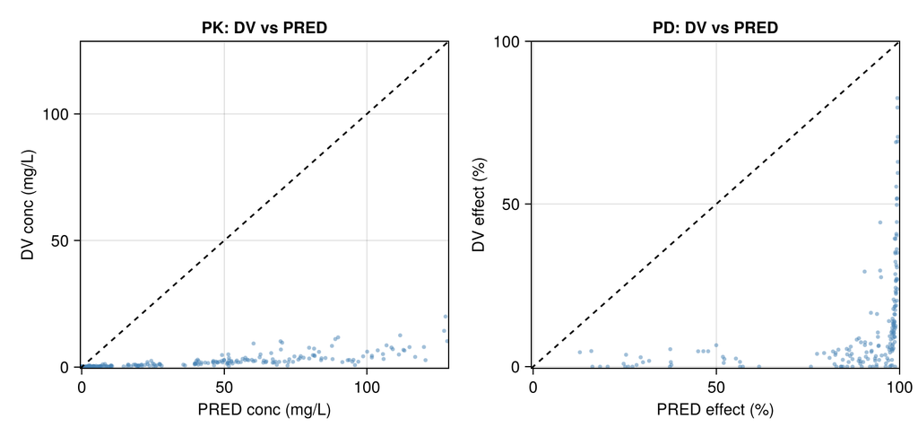

```julia
# Collect GOF data across population
DV_pk, PRED_pk, DV_pd, PRED_pd = Float32[], Float32[], Float32[], Float32[]

for (i, indv) in enumerate(mo_pop)
    ps_i, st_i = take_batch(ps_pkpd, st_pkpd, [i])
    ŷ = predict(model_pkpd, indv, ps_i, st_i)
    # ŷ[1] = plasma amounts; concentration = amount / V₁
    V₁_pred = predict_typ_parameters(model_pkpd, indv, ps_pkpd, st_pkpd)[1][2]  # index 2 = V₁
    pk_conc  = ŷ[1] ./ V₁_pred
    pd_pred  = emax_pd.(ŷ[2])   # apply Emax transformation to effect-site amounts

    append!(DV_pk,   indv.ys[1])
    append!(PRED_pk, pk_conc)
    append!(DV_pd,   indv.ys[2])
    append!(PRED_pd, pd_pred)
end

fig = Figure(size=(800, 380))
ax1 = Axis(fig[1,1], xlabel="PRED conc (mg/L)", ylabel="DV conc (mg/L)", title="PK: DV vs PRED")
ax2 = Axis(fig[1,2], xlabel="PRED effect (%)", ylabel="DV effect (%)",   title="PD: DV vs PRED")

for (ax, pred, obs) in [(ax1, PRED_pk, DV_pk), (ax2, PRED_pd, DV_pd)]
    lims = extrema([pred; obs]) .+ (-0.5f0, 0.5f0)
    scatter!(ax, pred, obs; color=(:steelblue, 0.5), markersize=5)
    lines!(ax, collect(lims), collect(lims); color=:black, linestyle=:dash)
    xlims!(ax, lims); ylims!(ax, lims)
end
fig
```

### Individual PK/PD time courses

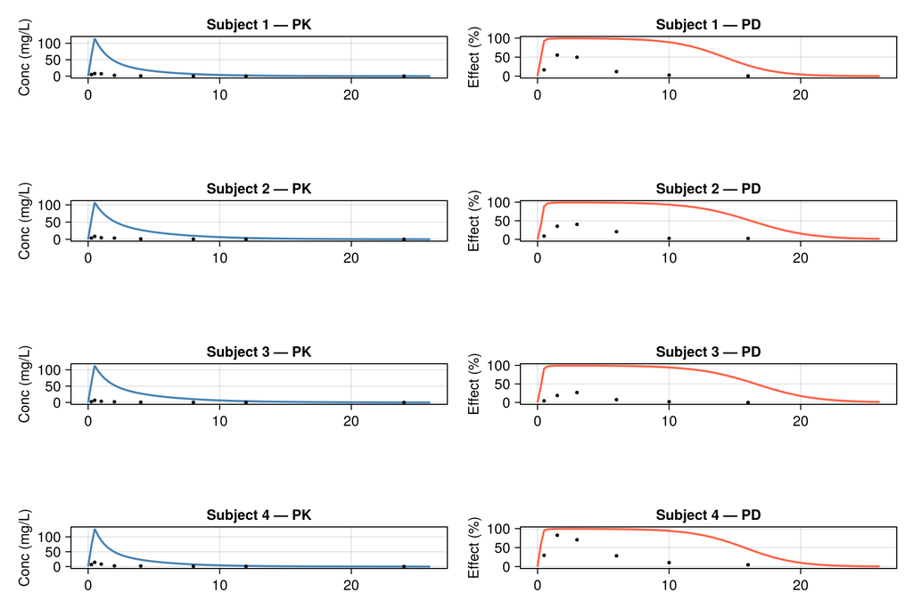

```julia
t_dense = Float32.(0:0.25:26)
fig = Figure(size=(900, 600))

for (i, indv) in enumerate(mo_pop[1:4])
    # PK panel
    ax_pk = Axis(fig[2i-1, 1], ylabel="Conc (mg/L)", title="Subject $(indv.id) — PK")
    ax_pd = Axis(fig[2i-1, 2], ylabel="Effect (%)",  title="Subject $(indv.id) — PD")

    ps_i, st_i = take_batch(ps_pkpd, st_pkpd, [i])
    ŷ = predict(model_pkpd, indv, ps_i, st_i; saveat=t_dense)
    V₁_pred = predict_typ_parameters(model_pkpd, indv, ps_pkpd, st_pkpd)[1][2]

    lines!(ax_pk, t_dense, ŷ[1] ./ V₁_pred; color=:steelblue, linewidth=2)
    scatter!(ax_pk, indv.t[indv.dvid[1]], indv.ys[1]; color=:black, markersize=5)

    lines!(ax_pd, t_dense, emax_pd.(ŷ[2]); color=:tomato, linewidth=2)
    scatter!(ax_pd, indv.t[indv.dvid[2]], indv.ys[2]; color=:black, markersize=5)
end
fig
```

### Residuals

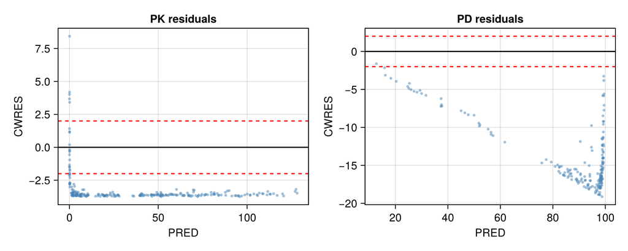

```julia
σ_pk = Lux.softplus(only(ps_pkpd.error.σ[1]))   # proportional σ
σ_pd = Lux.softplus(only(ps_pkpd.error.σ[2]))   # additive σ

cwres_pk = (DV_pk .- PRED_pk) ./ (PRED_pk .* σ_pk .+ 1f-6)
cwres_pd = (DV_pd .- PRED_pd) ./ σ_pd

fig = Figure(size=(800, 320))
ax1 = Axis(fig[1,1], xlabel="PRED", ylabel="CWRES", title="PK residuals")
ax2 = Axis(fig[1,2], xlabel="PRED", ylabel="CWRES", title="PD residuals")

for (ax, pred, cwres) in [(ax1, PRED_pk, cwres_pk), (ax2, PRED_pd, cwres_pd)]
    scatter!(ax, pred, cwres; color=(:steelblue, 0.5), markersize=5)
    hlines!(ax, [0f0]; color=:black)
    hlines!(ax, [-2f0, 2f0]; color=:red, linestyle=:dash)
end
fig
```

## Summary

| Concept | Implementation |
| --- | --- |
| Multiple responses | `MOIndividual(id, x, [t_pk, t_pd], [y_pk, y_pd], cb)` |
| Per-response error models | `ErrorModelSet(ProportionalError(), AdditiveError())` |
| Observed compartments | `DCM(...; target=[1, 3])` |
| Predictions per response | `predict(...)` returns `Vector{Vector}` |
| Residual scaling | Use `Lux.softplus(ps.error.σ[j])` for response `j` |